# Курсовая работа Practical Machine Learning

## Введение

В этой работе я буду строить модель для оценки качества выполнения физического упражнения - упражнения на подъём гантели. A - отличное выполнение упражнения, E - плохое. [Подробнее](http://groupware.les.inf.puc-rio.br/har#weight_lifting_exercises)

## Загрузка необходимых библиотек

Я буду использовать модель Random Forest, используя библиотеку машинного обучения Caret. Необходимо установить эти библиотеки и загрузить их в workspace:

```r
library(caret)
library(rpart)
library(e1071)
library(randomForest)
```

Для возможности повторить мои результаты я установлю seed (random number generator state):

```r
set.seed(1)
```

## Загрузка и очистка данных

[Набор данных, используемый для построения модели](https://d396qusza40orc.cloudfront.net/predmachlearn/pml-training.csv)

Для использования этот файл был предварительно загружен в working directory.

Для проверки коррекции модели я буду использовать cross-validation. Используя функцию createDataPartition из пакета caret, я разделю загруженные из csv файла “pml-training.csv” в переменную trainingSet данные на два набора - training (70% от всего набора) и test (30% от всего набора):

```r
trainingSet <- read.csv("pml-training.csv", na.strings=c("NA","#DIV/0!",""))

inTrain <- createDataPartition(y=trainingSet$classe, p=0.7, list=F)

training <- trainingSet[inTrain,]
test <- trainingSet[-inTrain,]
dim(training); dim(test)
```

```
## [1] 13737   160
```

```
## [1] 5885  160
```

В наборе достаточно много значений, которые объявлены не во всех измерениях. Для улучшения качества модели я решил их отфильтровать:

```r
sum(sapply(trainingSet, function(x) any(is.na(x))))
```

```
TRUE [1] 100
```

```r
removeColumnsWithNA <- function(x) x[,colSums(is.na(x))==0]
training <- removeColumnsWithNA(training)
test <- removeColumnsWithNA(test)
# проверим размер наборов
ncol(training); ncol(test)
```

```
TRUE [1] 60
```

```
TRUE [1] 60
```

Первые 5 колонок данных содержат мета данные сбора набора данных (номер, имя пользователя, время и прочее), некорректно использовать их при построении модели, поэтому мы их удалим.

```r
names(training[,1:5])
```

```
TRUE [1] "X"                    "user_name"            "raw_timestamp_part_1"
TRUE [4] "raw_timestamp_part_2" "cvtd_timestamp"
```

```r
trainingData <- training[,6:59]
trainingOut <- training[,60]

testData <- test[,6:59]
testOut <- test[,60]
```

## Построение модели

```r
modelRf <- train(trainingData,
                        trainingOut,
                        tuneGrid=data.frame(mtry=10),
                        trControl=trainControl(method="none"))
```

Информация о модели после обучения:

```
##
## Call:
##  randomForest(x = x, y = y, mtry = param$mtry)
##                Type of random forest: classification
##                      Number of trees: 500
## No. of variables tried at each split: 10
##
##         OOB estimate of  error rate: 0.26%
## Confusion matrix:
##      A    B    C    D    E  class.error
## A 3905    0    0    0    1 0.0002560164
## B    6 2649    3    0    0 0.0033860045
## C    0   10 2385    1    0 0.0045909850
## D    0    0   11 2241    0 0.0048845471
## E    0    0    0    4 2521 0.0015841584
```

## Тестирование и анализ полученной модели

```r
pred <- predict(modelRf, newdata=testData)

confusionMatrix(predict(modelRf,newdata=testData),testOut)
```

```
## Confusion Matrix and Statistics
##
##           Reference
## Prediction    A    B    C    D    E
##          A 1674    1    0    0    0
##          B    0 1138    2    0    0
##          C    0    0 1024    3    0
##          D    0    0    0  960    1
##          E    0    0    0    1 1081
##
## Overall Statistics
##
##                Accuracy : 0.9986
##                  95% CI : (0.9973, 0.9994)
##     No Information Rate : 0.2845
##     P-Value [Acc > NIR] : < 2.2e-16
##
##                   Kappa : 0.9983
##  Mcnemar's Test P-Value : NA
##
## Statistics by Class:
##
##                      Class: A Class: B Class: C Class: D Class: E
## Sensitivity            1.0000   0.9991   0.9981   0.9959   0.9991
## Specificity            0.9998   0.9996   0.9994   0.9998   0.9998
## Pos Pred Value         0.9994   0.9982   0.9971   0.9990   0.9991
## Neg Pred Value         1.0000   0.9998   0.9996   0.9992   0.9998
## Prevalence             0.2845   0.1935   0.1743   0.1638   0.1839
## Detection Rate         0.2845   0.1934   0.1740   0.1631   0.1837
## Detection Prevalence   0.2846   0.1937   0.1745   0.1633   0.1839
## Balanced Accuracy      0.9999   0.9994   0.9987   0.9978   0.9994
```

Как мы видим, точность на тестовых данных близка к 1. Отличный результат!

График важности значений измерений выглядит следующим образом:

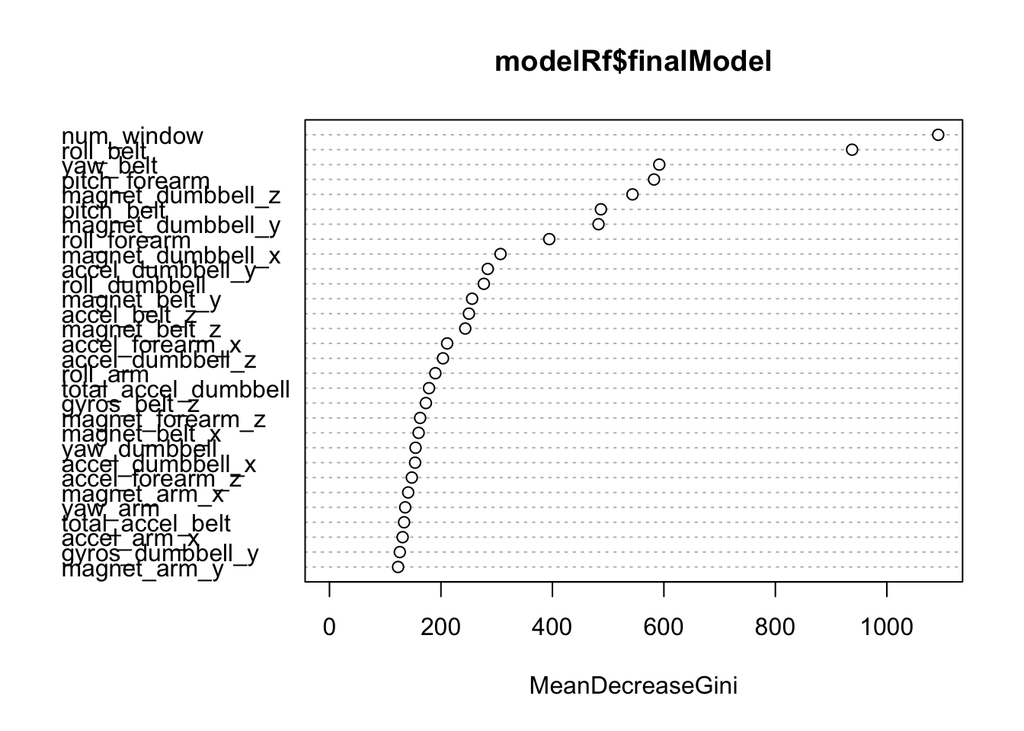

## Подведение результатов

Использование алгоритма Random Forest даёт отличные результаты для распознавания активности человека на основе данных акселерометров, закреплённых на его теле.